# Data Visualization - Mini-Project 1

Heilyn Gonzalez `hramirezabreu8662@floridapoly.edu`

# Getting the data

I have selected the *U.S births for the years 2000 to 2014* dataset for doing this project. This dataset has 5,479 observations and the data is presented by six variables that are year, month, date of month, day of week of week and the number of births. I will analyze the data by the observation the month and day of week that it is trending mothers to give births and the years that has the most births in the U.S between years 2000 and 2014.

```r
library(tidyverse)
birth <- read_csv("https://raw.githubusercontent.com/reisanar/datasets/master/us_births_00_14.csv")
birth
```

```
## # A tibble: 5,479 x 6
##     year month date_of_month date       day_of_week births
##    <dbl> <dbl>         <dbl> <date>     <chr>        <dbl>
##  1  2000     1             1 2000-01-01 Sat           9083
##  2  2000     1             2 2000-01-02 Sun           8006
##  3  2000     1             3 2000-01-03 Mon          11363
##  4  2000     1             4 2000-01-04 Tues         13032
##  5  2000     1             5 2000-01-05 Wed          12558
##  6  2000     1             6 2000-01-06 Thurs        12466
##  7  2000     1             7 2000-01-07 Fri          12516
##  8  2000     1             8 2000-01-08 Sat           8934
##  9  2000     1             9 2000-01-09 Sun           7949
## 10  2000     1            10 2000-01-10 Mon          11668
## # ... with 5,469 more rows
```

# Total of births

In the United States the total of births for the years 2000 to 2014 was 62,187,024. For analyzing the data by day of week, I will follow the steps below:

1. Summarize the data group by the weekday of birth.
2. Ordered the categorical data, in this case, the day of week.
3. Create a bar plot for showing the results.

```r
number_births<-birth %>%
    summarise(number_births=sum(births))

number_births
```

```
## # A tibble: 1 x 1
##   number_births
##           <dbl>
## 1      62187024
```

## Number of births by weekday

After getting the data by weekday, we have to organize that data because day of week is a categorical variable, and they must be ordered for representing then in a bar plot.

```r
number_births_weekday<-birth%>%
  group_by(day_of_week)%>%
  summarise(number_births_weekday=sum(births))%>%
  mutate(total=number_births_weekday)
number_births_weekday
```

```
## # A tibble: 7 x 3
##   day_of_week number_births_weekday    total
##   <chr>                       <dbl>    <dbl>
## 1 Fri                       9850199  9850199
## 2 Mon                       9316001  9316001
## 3 Sat                       6704495  6704495
## 4 Sun                       5886889  5886889
## 5 Thurs                    10045436 10045436
## 6 Tues                     10274874 10274874
## 7 Wed                      10109130 10109130
```

## Getting the weekdays ordered

```r
number_births_weekday$day_of_week<-factor(number_births_weekday$day_of_week, levels = c("Sun", "Mon", "Tues", "Wed", "Thurs", "Fri", "Sat"))
number_births_weekday<-number_births_weekday[order(number_births_weekday$day_of_week),]
```

After having ordered the data, I proceeded to represent the data in a bar plot using geom_col() and see which day of the week is more common for mothers to give birth and which one is not.

## Barplot of number of births by weekday

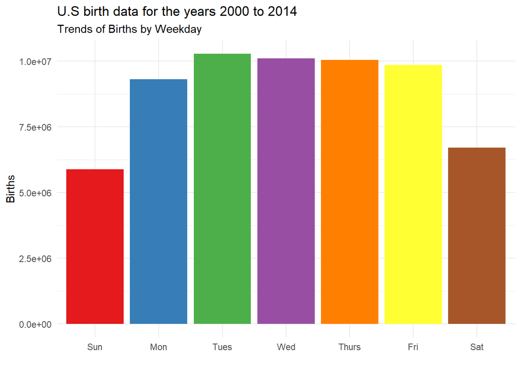

```r
ggplot(data=number_births_weekday, mapping = aes(x=day_of_week,y=total, fill=day_of_week)) + geom_col(position= "dodge") + theme_minimal() + scale_fill_brewer(palette = "Set1") + guides(fill=FALSE) +  labs(x = "",y = "Births", title = "U.S birth data for the years 2000 to 2014", subtitle = "Trends of Births by Weekday") + scale_color_brewer(palette = "Set2")
```

As is shown in the bar plot, the day of the week that is trending for births is Tuesday, it has a total of births of 10,274,874. However, Sunday looks like it is not common to give birth that day, it has a total of births of 5,886,889. I think most of births occurs in a unintentional day because their delivery method is natural, as it is explain in the paper [“Annual Summary of Vital Statistics:2013–2014”](https://pediatrics.aappublications.org/content/pediatrics/139/6/e20163239.full.pdf). However, if mothers have to deliver a baby by induction or c-section, for doctors and coming parents will not select a weekend day. Maybe, this is why Tuesday has the most number of births in the week.

## Total of births by months

According to our analysis, the day of the week that occurs more births is Tuesday. Now, I will proceed to check which month has the maximum number of births. For that we will do the following steps:

1. Summarize the data.
2. Organize our categorical variable.
3. Graphic representation of data.

## Summarize the data

```r
number_births_months<-birth%>%
  group_by(month)%>%
  summarise(number_births_months=sum(births))%>%
  mutate(total=number_births_months)
number_births_months
```

```
## # A tibble: 12 x 3
##    month number_births_months   total
##    <dbl>                <dbl>   <dbl>
##  1     1              5072588 5072588
##  2     2              4725693 4725693
##  3     3              5172961 5172961
##  4     4              4960750 4960750
##  5     5              5195445 5195445
##  6     6              5163360 5163360
##  7     7              5450418 5450418
##  8     8              5540170 5540170
##  9     9              5399592 5399592
## 10    10              5302865 5302865
## 11    11              5008750 5008750
## 12    12              5194432 5194432
```

## Converting months from numbers to month abbreviations

```r
number_births_months$month<-factor(number_births_months$month, levels = c("1","2","3","4","5","6","7","8","9","10","11","12"))
number_births_months<-number_births_months[order(number_births_months$month),]

mymonths <- c("Jan","Feb","Mar", "Apr","May","Jun", "Jul","Aug","Sep", "Oct","Nov","Dec")
number_births_months$MonthAbb <- mymonths[ number_births_months$month ]

number_births_months
```

```
## # A tibble: 12 x 4
##    month number_births_months   total MonthAbb
##    <fct>                <dbl>   <dbl> <chr>
##  1 1                  5072588 5072588 Jan
##  2 2                  4725693 4725693 Feb
##  3 3                  5172961 5172961 Mar
##  4 4                  4960750 4960750 Apr
##  5 5                  5195445 5195445 May
##  6 6                  5163360 5163360 Jun
##  7 7                  5450418 5450418 Jul
##  8 8                  5540170 5540170 Aug
##  9 9                  5399592 5399592 Sep
## 10 10                 5302865 5302865 Oct
## 11 11                 5008750 5008750 Nov
## 12 12                 5194432 5194432 Dec
```

## Getting the months ordered.

```r
number_births_months$MonthAbb<-factor(number_births_months$MonthAbb, levels = c("Jan","Feb","Mar", "Apr","May","Jun", "Jul","Aug","Sep", "Oct","Nov","Dec"))
number_births_months<-number_births_months[order(number_births_months$MonthAbb),]
```

## Scatterplot of births by months

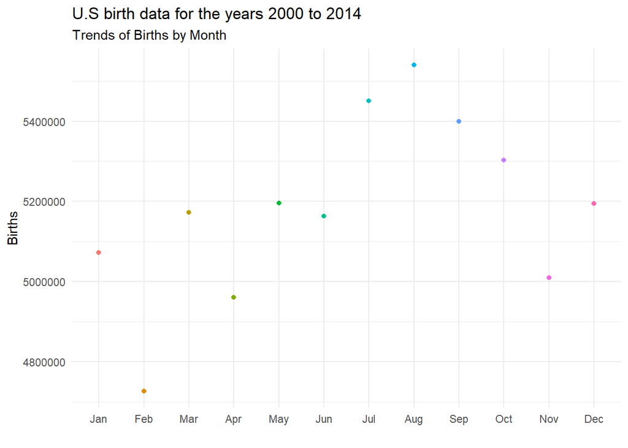

```r
ggplot(data=number_births_months, mapping = aes(x=MonthAbb, y=total, color=MonthAbb)) + geom_point() + theme_minimal()  + guides(color=FALSE) +  labs(x = "",y = "Births", title = "U.S birth data for the years 2000 to 2014", subtitle = "Trends of Births by Month")
```

## Number of births in U.S by years 2000 to 2014

For analyzing the number of births in the U.S for the years 2000 to 2014, I will summarize the data by year and make a graph for representing the results.

```r
number_births_years<-birth%>%
  group_by(year)%>%
  summarise(total=sum(births))
number_births_years
```

```
## # A tibble: 15 x 2
##     year   total
##    <dbl>   <dbl>
##  1  2000 4149598
##  2  2001 4110963
##  3  2002 4099313
##  4  2003 4163060
##  5  2004 4186863
##  6  2005 4211941
##  7  2006 4335154
##  8  2007 4380784
##  9  2008 4310737
## 10  2009 4190991
## 11  2010 4055975
## 12  2011 4006908
## 13  2012 4000868
## 14  2013 3973337
## 15  2014 4010532
```

## Trends of births by year

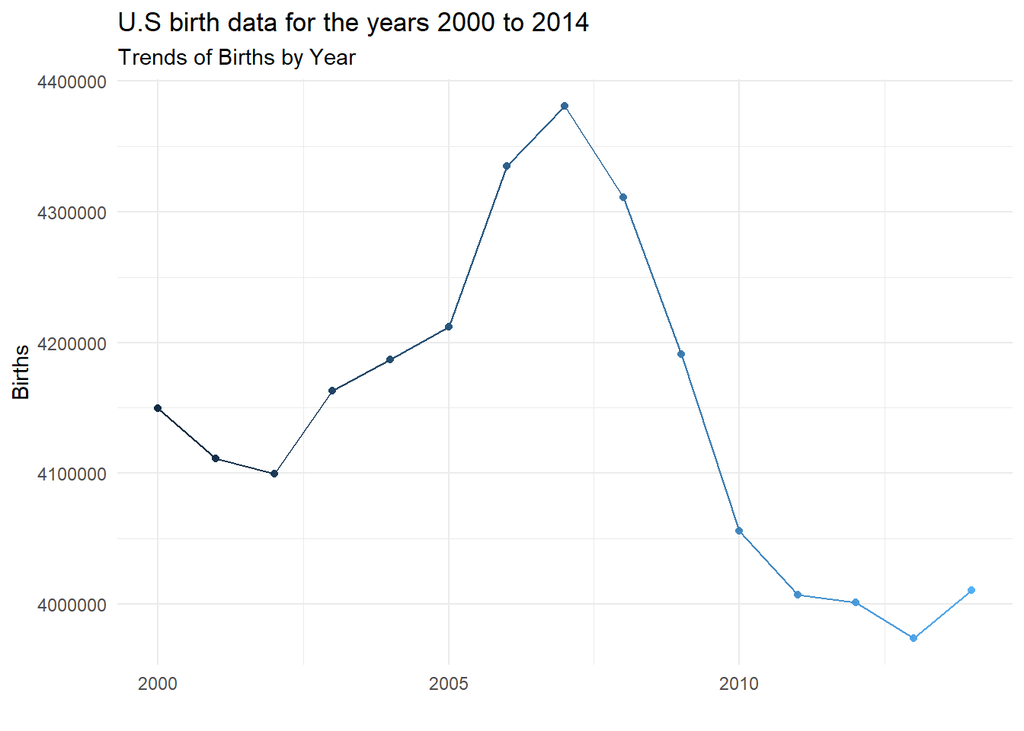

```r
ggplot(data=number_births_years, mapping = aes(x=year, y=total, color=year)) + geom_point() +   geom_line() + guides(color=FALSE) + theme_minimal() +  labs(x = "",y = "Births", title = "U.S birth data for the years 2000 to 2014", subtitle = "Trends of Births by Year")
```

This scatterplot shows that 2007 was the year with more number of births in the U.S but after that year the number of births tend to decrease.What was happening in the U.S after year 2007 ? Why the number of births decreased in a notable way? Well, the economic recession is the answer because economic conditions tend to affect fertility. The economic crisis that stared in U.S between 2007 and 2008 produce that number of births fell abruptly.